# Exploratory Data Analysis Project

#### Document your Analysis:

1. A stream-of-consciousness analysis and exploration of the data
   1. Headings and text should organize your thoughts and reflect your analysis as you explored the data.
   2. Plots in this analysis do not need to be polished with labels, units, and titles; these plots are exploratory (quick and dirty). They should, however, be of the appropriate type and effectively convey the information you glean from them.
   3. You can iterate on a plot in the same R chunk, but you don’t need to show every plot iteration in your analysis.
2. A section at the end called “Final Plots and Summary”
   1. You will select three plots from your analysis to polish and share in this section. The three plots should show different trends and should be polished with appropriate labels, units, and titles (see the Project Rubric for more information).
3. A final section called ‘Reflection’
   1. This should contain a few sentences about your struggles, successes, and ideas for future exploration on the data set (see the Project Rubric for more information)

# White Wine Dataset

#### Variables

- fixed acidity (tartaric acid - g / L): most acids involved with wine are fixed or nonvolatile (do not evaporate readily)
- volatile acidity (acetic acid - g / L): the amount of acetic acid in wine, which at too high of levels can lead to an unpleasant, vinegar taste
- citric acid (g / L): found in small quantities, citric acid can add ‘freshness’ and flavor to wines
- residual sugar (g / L): the amount of sugar remaining after fermentation stops, it’s rare to find wines with less than 1 gram/liter and wines with greater than 45 grams/liter are considered sweet
- chlorides (sodium chloride - g / L): the amount of salt in the wine
- free sulfur dioxide (mg / L): the free form of SO2 exists in equilibrium between molecular SO2 (as a dissolved gas) and bisulfite ion; it prevents microbial growth and the oxidation of wine
- total sulfur dioxide (mg / L): amount of free and bound forms of S02; in low concentrations, SO2 is mostly undetectable in wine, but at free SO2 concentrations over 50 ppm, SO2 becomes evident in the nose and taste of wine
- density (g / mL): the density of wine is close to that of water depending on the percent alcohol and sugar content
- pH: describes how acidic or basic a wine is on a scale from 0 (very acidic) to 14 (very basic); most wines are between 3-4 on the pH scale
- sulphates (potassium sulphate - g / L): a wine additive which can contribute to sulfur dioxide gas (S02) levels, wich acts as an antimicrobial and antioxidant
- alcohol (% by volume): the percent alcohol content of the wine
- quality (score between 0 and 10)

# ANALYSIS

#### Useful Conversions:

- 1 dm^3 = 1 L
- 1 cm^3 = 1 mL
- 1000 ppm = 1 g/L = 1000 mg/L

#### Important to note:

- All correlations looked at are for linear models
- All volumes have been changed from a cubic length unit to a volume unit by personal preference

### Guiding Question: Which chemical properties influence the quality of white wines?

#### Checkout the variables to see the datasets structure

```
'data.frame':   4898 obs. of  13 variables:
 $ X                   : int  1 2 3 4 5 6 7 8 9 10 ...
 $ fixed.acidity       : num  7 6.3 8.1 7.2 7.2 8.1 6.2 7 6.3 8.1 ...
 $ volatile.acidity    : num  0.27 0.3 0.28 0.23 0.23 0.28 0.32 0.27 0.3 0.22 ...
 $ citric.acid         : num  0.36 0.34 0.4 0.32 0.32 0.4 0.16 0.36 0.34 0.43 ...
 $ residual.sugar      : num  20.7 1.6 6.9 8.5 8.5 6.9 7 20.7 1.6 1.5 ...
 $ chlorides           : num  0.045 0.049 0.05 0.058 0.058 0.05 0.045 0.045 0.049 0.044 ...
 $ free.sulfur.dioxide : num  45 14 30 47 47 30 30 45 14 28 ...
 $ total.sulfur.dioxide: num  170 132 97 186 186 97 136 170 132 129 ...
 $ density             : num  1.001 0.994 0.995 0.996 0.996 ...
 $ pH                  : num  3 3.3 3.26 3.19 3.19 3.26 3.18 3 3.3 3.22 ...
 $ sulphates           : num  0.45 0.49 0.44 0.4 0.4 0.44 0.47 0.45 0.49 0.45 ...
 $ alcohol             : num  8.8 9.5 10.1 9.9 9.9 10.1 9.6 8.8 9.5 11 ...
 $ quality             : Factor w/ 7 levels "3","4","5","6",..: 4 4 4 4 4 4 4 4 4 4 ...
'data.frame':   4898 obs. of  13 variables:
 $ X                   : int  1 2 3 4 5 6 7 8 9 10 ...
 $ fixed.acidity       : num  7 6.3 8.1 7.2 7.2 8.1 6.2 7 6.3 8.1 ...
 $ volatile.acidity    : num  0.27 0.3 0.28 0.23 0.23 0.28 0.32 0.27 0.3 0.22 ...
 $ citric.acid         : num  0.36 0.34 0.4 0.32 0.32 0.4 0.16 0.36 0.34 0.43 ...
 $ residual.sugar      : num  20.7 1.6 6.9 8.5 8.5 6.9 7 20.7 1.6 1.5 ...
 $ chlorides           : num  0.045 0.049 0.05 0.058 0.058 0.05 0.045 0.045 0.049 0.044 ...
 $ free.sulfur.dioxide : num  45 14 30 47 47 30 30 45 14 28 ...
 $ total.sulfur.dioxide: num  170 132 97 186 186 97 136 170 132 129 ...
 $ density             : num  1.001 0.994 0.995 0.996 0.996 ...
 $ pH                  : num  3 3.3 3.26 3.19 3.19 3.26 3.18 3 3.3 3.22 ...
 $ sulphates           : num  0.45 0.49 0.44 0.4 0.4 0.44 0.47 0.45 0.49 0.45 ...
 $ alcohol             : num  8.8 9.5 10.1 9.9 9.9 10.1 9.6 8.8 9.5 11 ...
 $ quality             : Factor w/ 7 levels "3","4","5","6",..: 4 4 4 4 4 4 4 4 4 4 ...
```

#### Look at groupings of the chemical properties of wine to get a feel for range of values, if input features are correlated, and which features might likely effect quality.

#### Acidity

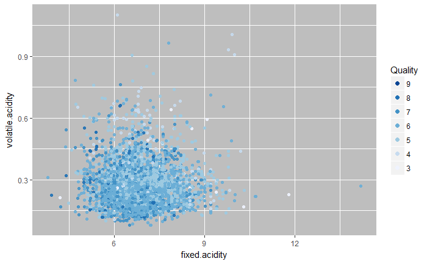

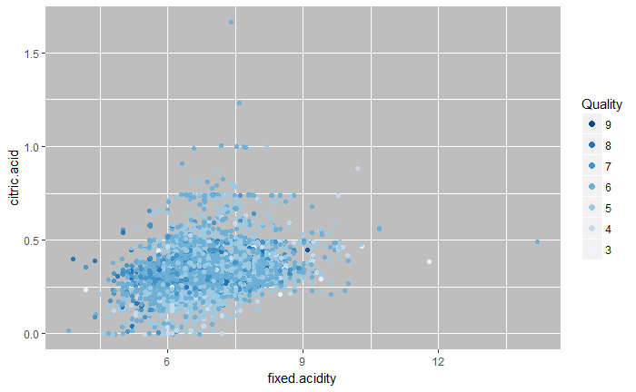

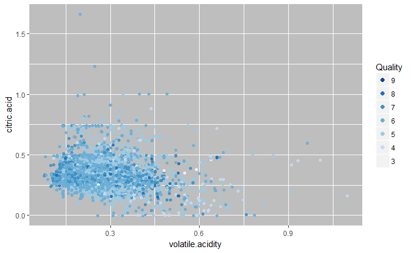

- Large cluster of wine with volatile acidity (0.15-0.60 g/L) and fixed acidity (4.5-9.0 g/L)
- Citric acid levels seem to be clustered below concentration (< 0.5 g/L)
- At first glance, lower concentration of acidity corresponds to increasing quality

#### Could high volatile acidity effect quality?

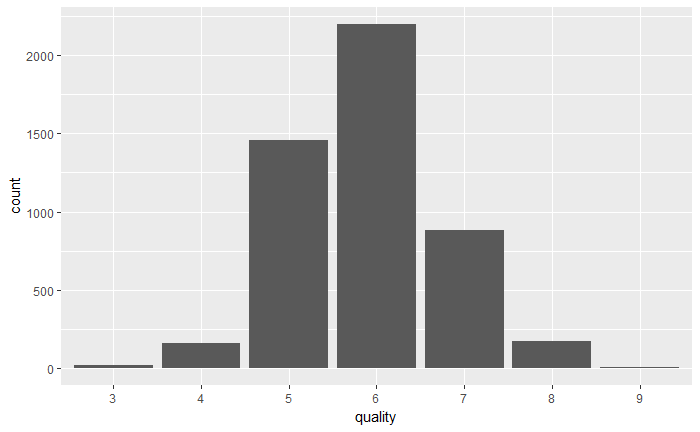

```
[1] "Counts for Quality Ratings"

   3    4    5    6    7    8    9
  20  163 1457 2198  880  175    5
```

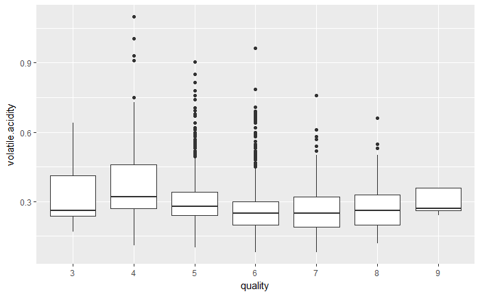

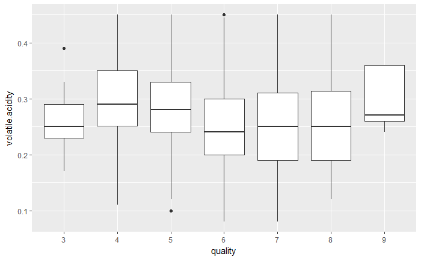

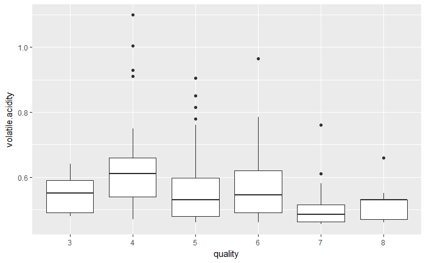

```
[1] "Full dataset"

    Pearson's product-moment correlation

data:  as.numeric(quality) and volatile.acidity
t = -13.891, df = 4896, p-value < 2.2e-16
alternative hypothesis: true correlation is not equal to 0
95 percent confidence interval:
 -0.2215214 -0.1676307
sample estimates:
      cor
-0.194723

[1] "Subset with volatile.acidity <= 0.45"

    Pearson's product-moment correlation

data:  as.numeric(quality) and volatile.acidity
t = -9.9172, df = 4640, p-value < 2.2e-16
alternative hypothesis: true correlation is not equal to 0
95 percent confidence interval:
 -0.1721263 -0.1157827
sample estimates:
       cor
-0.1440712

[1] "Subset with volatile.acidity > 0.45"

    Pearson's product-moment correlation

data:  as.numeric(quality) and volatile.acidity
t = -4.2265, df = 254, p-value = 3.313e-05
alternative hypothesis: true correlation is not equal to 0
95 percent confidence interval:
 -0.3673881 -0.1380690
sample estimates:
       cor
-0.2563319
```

- Quality looks to have a normal distribution. There are far fewer examples for quality ratings of 3, 4, 8, and 9.
- Quality and volatile acidity are negatively correlated likely because at higher concentrations the acidity may be unpleasant to the drinker.
- Subsetting the data to an arbitrary level of volatile acidity (> 0.45 g/L) that includes more outliers, indicates that a stronger negative correlation exists at these extremes relative to the remainder of the dataset.

#### Does pH play a factor in quality?

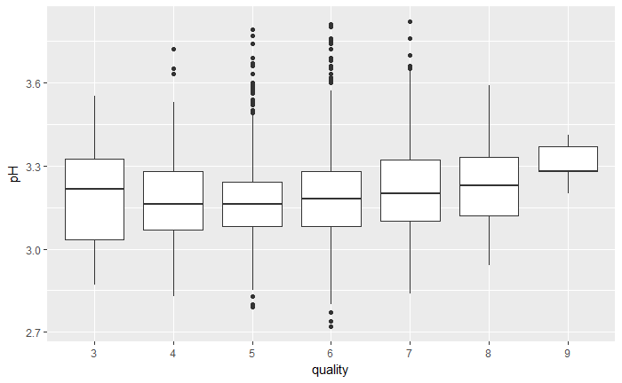

```
[1] "pH Values across Quality Ratings"
whites$quality: 3
   Min. 1st Qu.  Median    Mean 3rd Qu.    Max.
  2.870   3.035   3.215   3.188   3.325   3.550
------------------------------------------------------------------------------------------------------------
whites$quality: 4
   Min. 1st Qu.  Median    Mean 3rd Qu.    Max.
  2.830   3.070   3.160   3.183   3.280   3.720
------------------------------------------------------------------------------------------------------------
whites$quality: 5
   Min. 1st Qu.  Median    Mean 3rd Qu.    Max.
  2.790   3.080   3.160   3.169   3.240   3.790
------------------------------------------------------------------------------------------------------------
whites$quality: 6
   Min. 1st Qu.  Median    Mean 3rd Qu.    Max.
  2.720   3.080   3.180   3.189   3.280   3.810
------------------------------------------------------------------------------------------------------------
whites$quality: 7
   Min. 1st Qu.  Median    Mean 3rd Qu.    Max.
  2.840   3.100   3.200   3.214   3.320   3.820
------------------------------------------------------------------------------------------------------------
whites$quality: 8
   Min. 1st Qu.  Median    Mean 3rd Qu.    Max.
  2.940   3.120   3.230   3.219   3.330   3.590
------------------------------------------------------------------------------------------------------------
whites$quality: 9
   Min. 1st Qu.  Median    Mean 3rd Qu.    Max.
  3.200   3.280   3.280   3.308   3.370   3.410

    Pearson's product-moment correlation

data:  as.numeric(quality) and pH
t = 6.9917, df = 4896, p-value = 3.081e-12
alternative hypothesis: true correlation is not equal to 0
95 percent confidence interval:
 0.07162022 0.12707983
sample estimates:
       cor
0.09942725
```

- 25-75% quantile range does not vary much (within 0.3 units) between quality groups
- pH has a very weak positive correlation with quality, probably not a useful feature for a linear model

#### Sugar, ions, and density

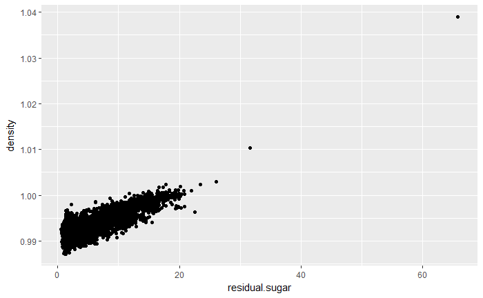

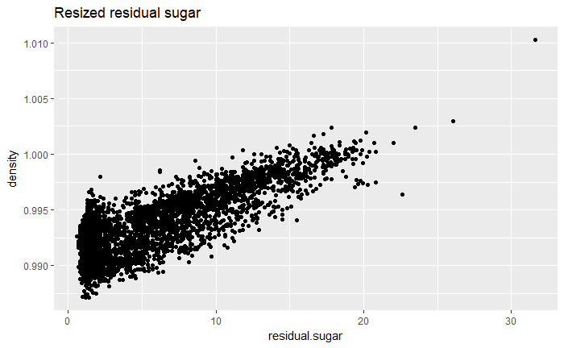

```
[1] "Summary of Residual Sugar"
   Min. 1st Qu.  Median    Mean 3rd Qu.    Max.
  0.600   1.700   5.200   6.391   9.900  65.800
```

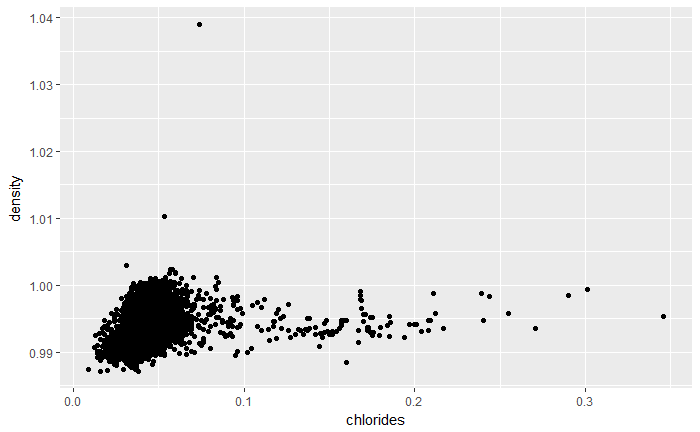

```
[1] "Summary of Chlorides"
   Min. 1st Qu.  Median    Mean 3rd Qu.    Max.
0.00900 0.03600 0.04300 0.04577 0.05000 0.34600
```

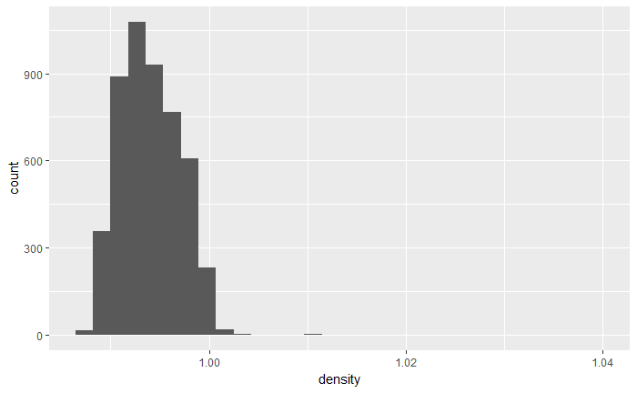

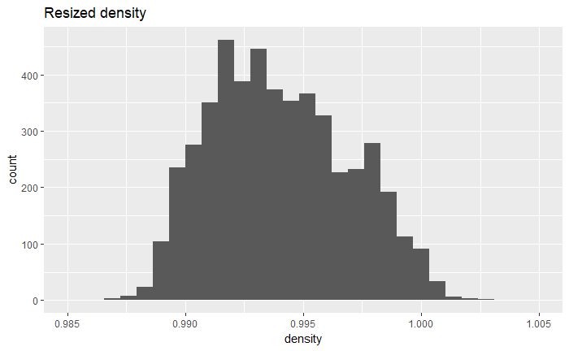

```
[1] "Summary of Density"
   Min. 1st Qu.  Median    Mean 3rd Qu.    Max.
 0.9871  0.9917  0.9937  0.9940  0.9961  1.0390

    Pearson's product-moment correlation

data:  as.numeric(quality) and density
t = -22.581, df = 4896, p-value < 2.2e-16
alternative hypothesis: true correlation is not equal to 0
95 percent confidence interval:
 -0.3322718 -0.2815385
sample estimates:
       cor
-0.3071233
```

#### Taking a look at quality vs density

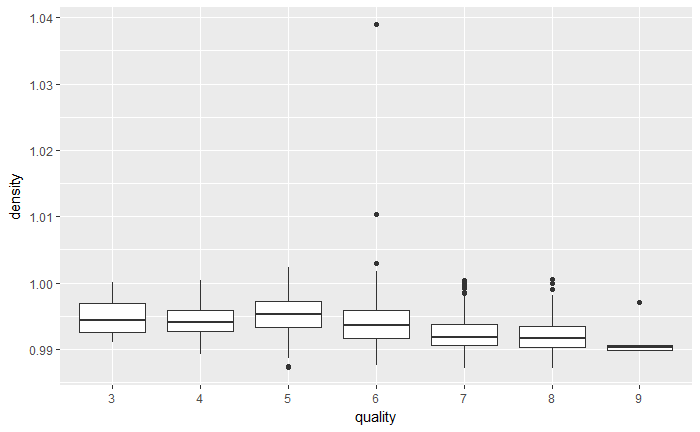

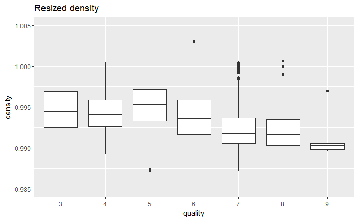

```
    Pearson's product-moment correlation

data:  as.numeric(quality) and density
t = -22.581, df = 4896, p-value < 2.2e-16
alternative hypothesis: true correlation is not equal to 0
95 percent confidence interval:
 -0.3322718 -0.2815385
sample estimates:
       cor
-0.3071233
```

- Box plot shows a roughly negative correlation between quality and density
- Considering that density is determined by make up of the wine (solutes (ions, sugars, acids, etc), solvents (water, alcohol)) and that solvents are the largest contributor to a mixtures density, may want to look at alcohol and its relation to quality.

#### Does alcohol content contribute to the quality of wine?

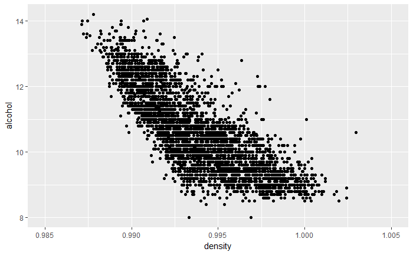

```
    Pearson's product-moment correlation

data:  density and alcohol
t = -87.255, df = 4896, p-value < 2.2e-16
alternative hypothesis: true correlation is not equal to 0
95 percent confidence interval:
 -0.7908646 -0.7689315
sample estimates:
       cor
-0.7801376
```

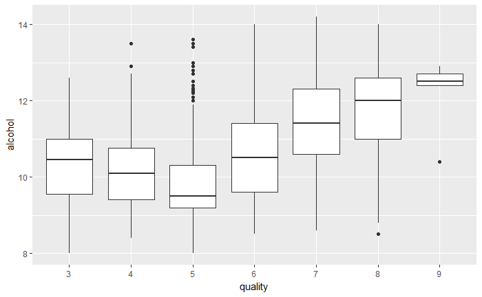

```
    Pearson's product-moment correlation

data:  as.numeric(quality) and alcohol
t = 33.858, df = 4896, p-value < 2.2e-16
alternative hypothesis: true correlation is not equal to 0
95 percent confidence interval:
 0.4126015 0.4579941
sample estimates:
      cor
0.4355747
```

- Since as alcohol content increases wine density decreases (r = -0.78), the correlation of density with quality is probably more of a factor of alcohol concentration than density.
- This is apparent from the higher R-squared value for alcohol/quality than density/quality

#### Checking sulfurous contents

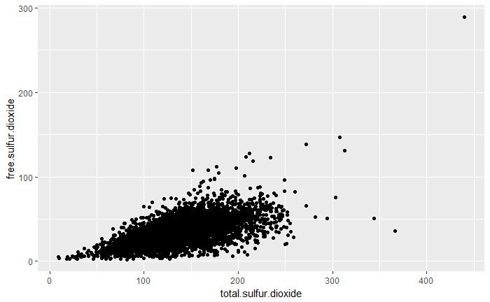

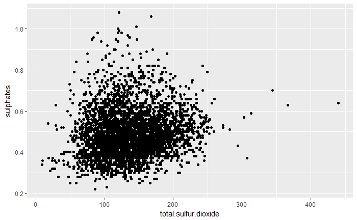

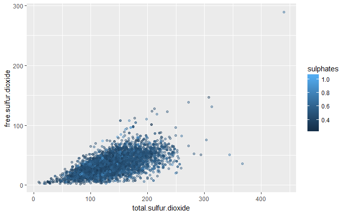

```
    Pearson's product-moment correlation

data:  total.sulfur.dioxide and free.sulfur.dioxide
t = 54.645, df = 4896, p-value < 2.2e-16
alternative hypothesis: true correlation is not equal to 0
95 percent confidence interval:
 0.5977994 0.6326026
sample estimates:
     cor
0.615501


    Pearson's product-moment correlation

data:  total.sulfur.dioxide and sulphates
t = 9.5019, df = 4896, p-value < 2.2e-16
alternative hypothesis: true correlation is not equal to 0
95 percent confidence interval:
 0.1069590 0.1619585
sample estimates:
      cor
0.1345624


    Pearson's product-moment correlation

data:  sulphates and free.sulfur.dioxide
t = 4.1508, df = 4896, p-value = 3.369e-05
alternative hypothesis: true correlation is not equal to 0
95 percent confidence interval:
 0.03126264 0.08707928
sample estimates:
       cor
0.05921725
```

- Note that sulfur dioxide concentrations are in mg/L vs sulphates which is in g/L
- Total sulfur dioxide has a moderate positive correlation with free sulfur dioxide concentrations, while both variables have weak positive correlations with sulphate concentration
- Note that a significant amount of wines have free sulfur dioxide concentrations greater than 50 ppm (0.05 g/L or 50 mg/L) which can be unpleasant; may want to subset that data since sulfur dioxide will then be detectable by smell by given definition

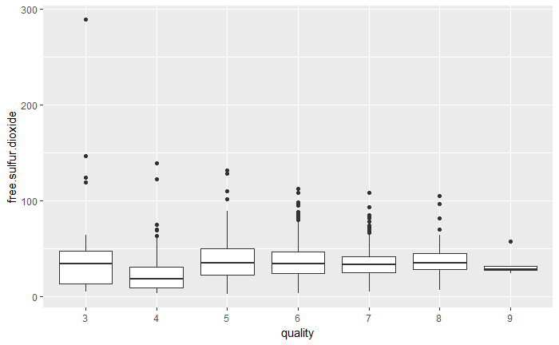

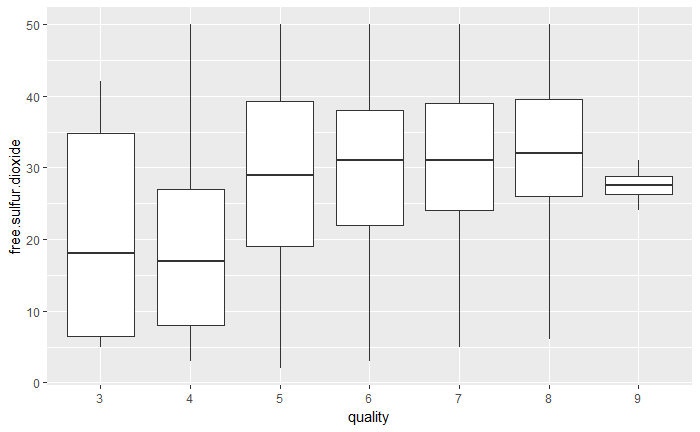

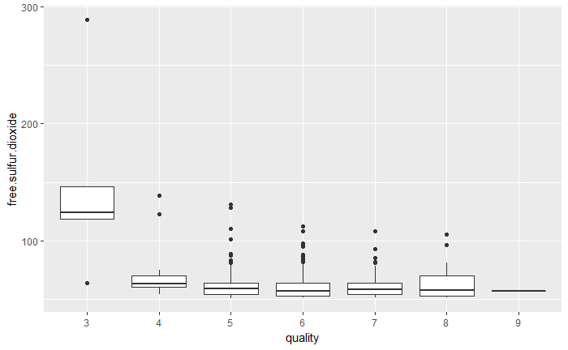

```
[1] "Full Dataset"

    Pearson's product-moment correlation

data:  as.numeric(quality) and free.sulfur.dioxide
t = 0.57085, df = 4896, p-value = 0.5681
alternative hypothesis: true correlation is not equal to 0
95 percent confidence interval:
 -0.01985292  0.03615626
sample estimates:
        cor
0.008158067

[1] "Subset with free.sulfur.dioxide <= 50"

    Pearson's product-moment correlation

data:  as.numeric(quality) and free.sulfur.dioxide
t = 10.337, df = 4028, p-value < 2.2e-16
alternative hypothesis: true correlation is not equal to 0
95 percent confidence interval:
 0.1305243 0.1906818
sample estimates:
      cor
0.1607524

[1] "Subset with free.sulfur.dioxide > 50"

    Pearson's product-moment correlation

data:  as.numeric(quality) and free.sulfur.dioxide
t = -3.812, df = 866, p-value = 0.0001476
alternative hypothesis: true correlation is not equal to 0
95 percent confidence interval:
 -0.19335188 -0.06245395
sample estimates:
       cor
-0.1284624
```

- There exists no significant correlation of quality with free sulfur dioxide concentration, but when the dataset is subset to detectable free sulfur dioxide by smell (concentration >= 50 ppm) and nondetectable free sulfur dioxide by smell (concentration < 50 ppm) there exists a significant negative and positive correlation respectively.

### Creating a Linear Model to determine quality

```
[1] "Full dataset"

Calls:
x1: lm(formula = as.numeric(quality) ~ alcohol, data = whites)
x2: lm(formula = as.numeric(quality) ~ alcohol + volatile.acidity,
    data = whites)
x3: lm(formula = as.numeric(quality) ~ alcohol + volatile.acidity +
    free.sulfur.dioxide, data = whites)

=================================================================
                            x1            x2            x3
-----------------------------------------------------------------
  (Intercept)              0.582***      1.017***      0.604***
                          (0.098)       (0.098)       (0.109)
  alcohol                  0.313***      0.324***      0.343***
                          (0.009)       (0.009)       (0.009)
  volatile.acidity                      -1.979***     -1.904***
                                        (0.110)       (0.109)
  free.sulfur.dioxide                                  0.006***
                                                      (0.001)
-----------------------------------------------------------------
  R-squared                0.190         0.240         0.251
  adj. R-squared           0.190         0.240         0.250
  sigma                    0.797         0.772         0.767
  F                     1146.395       773.875       546.017
  p                        0.000         0.000         0.000
  Log-likelihood       -5839.391     -5681.776     -5647.564
  Deviance              3112.257      2918.264      2877.780
  AIC                  11684.782     11371.552     11305.127
  BIC                  11704.272     11397.538     11337.610
  N                     4898          4898          4898
=================================================================
[1] "Subset of non-smelly wines"

Calls:
m1: lm(formula = as.numeric(quality) ~ alcohol, data = subset(whites,
    free.sulfur.dioxide <= 50))
m2: lm(formula = as.numeric(quality) ~ alcohol + volatile.acidity,
    data = subset(whites, free.sulfur.dioxide <= 50))
m3: lm(formula = as.numeric(quality) ~ alcohol + volatile.acidity +
```

[output cut: 45 more lines]

```
                                      (0.283)      (0.279)
  free.sulfur.dioxide                              -0.009***
                                                   (0.002)
--------------------------------------------------------------
  R-squared               0.198        0.247        0.270
  adj. R-squared          0.197        0.246        0.267
  sigma                   0.723        0.701        0.691
  F                     214.004      142.213      106.369
  p                       0.000        0.000        0.000
  Log-likelihood       -949.065     -921.527     -908.490
  Deviance              452.642      424.813      412.242
  AIC                  1904.131     1851.054     1826.981
  BIC                  1918.429     1870.119     1850.812
  N                     868          868          868
==============================================================
```

- Subsetting the free sulfur dioxide feature shows a slight improvement in overall R^2 with the combined linear model (alcohol, volatile.acidity, free.sulfur.dioxide) vs not-subsetting the free sulfur dioxide feature

# Final Plots and Summary

### Plot One

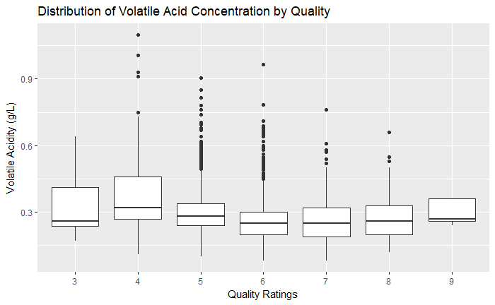

```
    Pearson's product-moment correlation

data:  as.numeric(quality) and volatile.acidity
t = -13.891, df = 4896, p-value < 2.2e-16
alternative hypothesis: true correlation is not equal to 0
95 percent confidence interval:
 -0.2215214 -0.1676307
sample estimates:
      cor
-0.194723
```

- Quality looks to increase with decreasing volatile acid concentration. There seems to be a number of outliers in the distribution of quality ratings 5 and 6, which is reflective of the higher count amounts for those categories.

### Plot Two

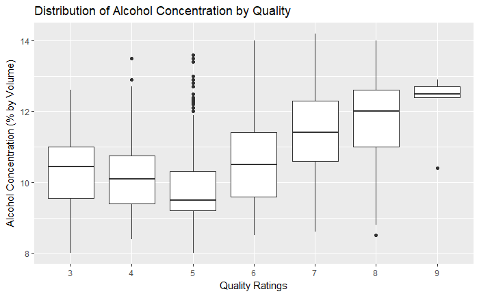

```
    Pearson's product-moment correlation

data:  as.numeric(quality) and alcohol
t = 33.858, df = 4896, p-value < 2.2e-16
alternative hypothesis: true correlation is not equal to 0
95 percent confidence interval:
 0.4126015 0.4579941
sample estimates:
      cor
0.4355747
```

- Quality tends to increase with increasing alcohol concentration. Although the median alcohol concentration increases from quality rating of 5 to 4 and 3.

### Plot Three

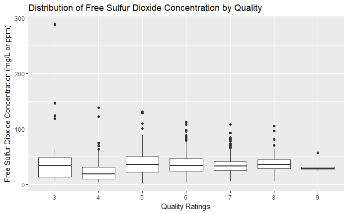

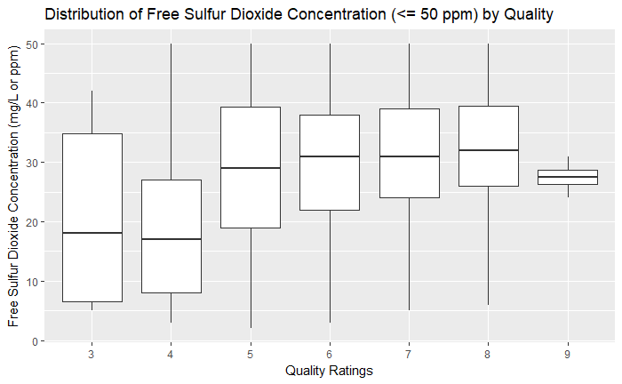

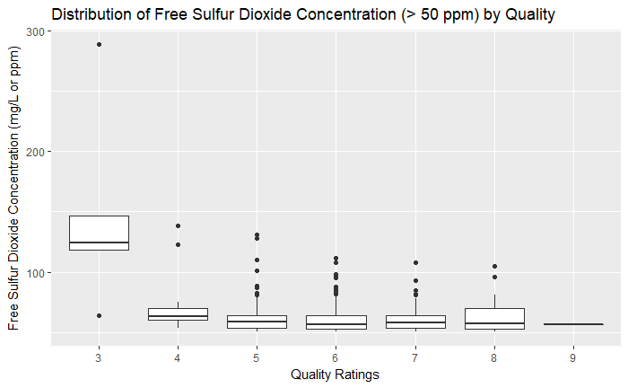

```
[1] "Full Dataset"

    Pearson's product-moment correlation

data:  as.numeric(quality) and free.sulfur.dioxide
t = 0.57085, df = 4896, p-value = 0.5681
alternative hypothesis: true correlation is not equal to 0
95 percent confidence interval:
 -0.01985292  0.03615626
sample estimates:
        cor
0.008158067

[1] "Subset with free.sulfur.dioxide <= 50"

    Pearson's product-moment correlation

data:  as.numeric(quality) and free.sulfur.dioxide
t = 10.337, df = 4028, p-value < 2.2e-16
alternative hypothesis: true correlation is not equal to 0
95 percent confidence interval:
 0.1305243 0.1906818
sample estimates:
      cor
0.1607524

[1] "Subset with free.sulfur.dioxide > 50"

    Pearson's product-moment correlation

data:  as.numeric(quality) and free.sulfur.dioxide
t = -3.812, df = 866, p-value = 0.0001476
alternative hypothesis: true correlation is not equal to 0
95 percent confidence interval:
 -0.19335188 -0.06245395
sample estimates:
       cor
-0.1284624
```

- Distribution of free sulfur dioxide concentrations for wine samples seems to show very little difference across quality ratings by looking at median value.
- Subsetting for free sulfur dioxide concentrations above and below 50 ppm shows an inflection point. Quality ratings increase with increasing free sulfur dioxide concentrations in the subset with concentrations less than 51 ppm, whilc quality ratings decreased with increasing free sulfur dioxide concentrations in the subset with concentrations above 50 ppm.

# Reflection

- I began my analysis by looking at features individually or as a cluster to see if they convey similar information (ie. acidity). I then proceeded to look more deeply at features I thought were more easily perceptible to a drinker to see if they correlated with quality.
- Looking at particular definitions of the features, volatile acidity and free sulfur dioxide stood out as being important to the sense of smell. Since smell contributes significantly to our perception of taste (or quality in this case), I dived deeper to see if they correlated significantly with quality of the wine. This inference ended up being true in regards to free sulfur dioxide concentration and volatile acid concentrations.
- Looking more deeply at the density feature, which I initially thought wasn’t going to be useful as a feature because of the very narrow range of values, pointed to a significant negative correlation with quality. This led me to the alcohol by volume feature because of it’s strong negative correlation with density. Alcohol ended up showing a signifant positive correlation with quality and was the largest factor in determining the percent variance (R^2) for quality.
- It was difficult to make a linear model to determine quality with the given features. All of the features looked to have a mostly non-linear correlation with quality. It would likely be more useful to use a machine learning algorithm to predict quality from the given features.
- Also, there was far more examples of wines with a quality ratings of 5, 6, and 7 when an even distribution count for all ratings may have helped to discern more prominent features of wines with qualities of 3, 4, 8, and 9 for a better model for quality predictions. This property of the data also made using a facet wrap to compare distributions ineffective.